# Lab 4 – Sampling Distributions

## Load packages, data, and lab template

Run the code below to download the lab template, load the democracy score data, and call the `tidyverse` and `infer` packages. You will have to install the `infer` package and download the data set for today’s lab before running the code below. Today we will be working with data from *The Economist’s* [Democracy Index](https://www.eiu.com/n/campaigns/democracy-index-2020/). These scores are used to rank the extent to which a country is democratic, with a potential high of 10 and low of 0.

Today’s data comes in the format of an Excel file. The process for loading the data into the Docker is similar as the CSV last week; however, instead of `read_csv` (or `read.csv`), you should use the `read_excel` (or `read.excel`) command.

```r
# DOWNLOAD THE TEMPLATE
download.file("https://jacobfhsmith.github.io/STA101-Fall-2021/sta101_lab4.Rmd", destfile="sta101_lab4.Rmd")

# Tidyverse loads ggplot2 and dplyr packages (and many others)
library(tidyverse)

# The infer package gives us the rep_sample_n() function (used below)
library(infer)

# Load in the data we will be using- first, call the readxl package.
library(readxl)

# YOU MAY NEED TO CHANGE THE FILE PATH
democracy <- read_excel("~/democracy_score.xlsx")
```

## Dplyr

Various functions from the `dplyr` package were introduced in previous labs. Recall some of the common functions: *select()*, *mutate()*, *transmute()*, *filter()*, *group_by()*, *arrange()*, *count()*, *summarise()*, *slice()*, *sample_n()*, etc. Remember to use ? followed by the function name in the R console to view the function documentation i.e. ?select. Also, see the data wrangling cheat sheet for examples: https://rstudio.com/wp-content/uploads/2015/02/data-wrangling-cheatsheet.pdf.

### Review: Pipeline operator %>%

To review, this is an operator in the `dplyr` package that can make your coding easier and more readable, especially when you have many functions in your ‘pipeline’ (sequence of functions being applied to a data frame). Let’s say we want to select a variable from a data set (we’ll use `mpg` again), group by a categorical variable, and obtain the largest three values within each category. What would you do?

```r
mpg %>%
  select(cty, manufacturer, class) %>%
  group_by(manufacturer, class) %>%
  arrange(desc(cty), .by_group = T) %>%
  slice(1:3) %>%
  head(3)
```

```
## # A tibble: 3 x 3
## # Groups:   manufacturer, class [1]
##     cty manufacturer class
##   <int> <chr>        <chr>
## 1    21 audi         compact
## 2    21 audi         compact
## 3    20 audi         compact
```

What would this be without *%>%*?

```r
head(slice(arrange(group_by(select(mpg, cty, manufacturer, class), manufacturer, class), desc(cty), .by_group = T), 1:3), 3)
```

```
## # A tibble: 3 x 3
## # Groups:   manufacturer, class [1]
##     cty manufacturer class
##   <int> <chr>        <chr>
## 1    21 audi         compact
## 2    21 audi         compact
## 3    20 audi         compact
```

**Question for discussion:** What are some advantages to using the pipeline?

## Sampling distributions

A sample statistic is simply a function of a random sample. Some examples include the sample mean (sum the sample values and divide by the sample size) and sample median (order the samples and find the middle value). The distribution of a statistic is called a sampling distribution. For example, compare the two statements:

1. “What’s the chance that the lifetime of a light bulb is greater than 750 hours?”
2. “What’s the chance that the average lifetime of 100 light bulbs is greater than 750 hours?”

These two statements are similar (‘the chance *some number* is greater than 750’), but the top concerns a single observation while the bottom concerns 100 samples. To answer the bottom question, we will need to know the distribution of the sample mean.

##### The Central Limit Theorem (CLT)

Question one can often be very challenging to directly answer while question two can be very easy (provided we sample enough light bulbs). This is due to the *Central Limit Theorem (CLT)*. The CLT basically states that the distribution of the sample mean will be approximately normal for a large enough sample size. In the context above, this means that the distribution of the sample average of 100 (or 100,000) light bulbs will look normally distributed, even though the distribution of a *single* light bulb might be highly skewed and non-normal.

##### Standard error

The *standard error* is simply the standard deviation of the sampling distribution.

For example, if we kept taking 100 light bulbs off of a factory line and computing the average lifetime, we would expect the average lifetime itself to vary between samples of size 100. This variability is due to the randomness of the individual light bulbs, so the variability of the sample mean and the individual light bulbs is related, but not exactly the same. To avoid confusion, we will call the standard deviation of the average lifetime the *standard error* and the standard deviation of an individual light bulb…well…the standard deviation.

### Reminder: setting a random seed

In this lab, we will be simulating random numbers. In order to make your work reproducible, you will need to set a ‘seed’ at the beginning of your code. In doing so, each time you knit your document the same random numbers are generated. Note that if you set a seed in your R console and begin simulating random numbers, different numbers will appear each time; only by knitting the document will you see the same random numbers produced. Uncomment the code below to set a seed.

```r
# Uncomment the code below to set a seed. Replace '?' with any number you like.
# set.seed(?)
```

##### CLT Example

Let’s see the CLT in action. We set a seed and then plot a histogram of overall democracy scores. Looking at the density plot below, do you think democracy scores are normally distributed?

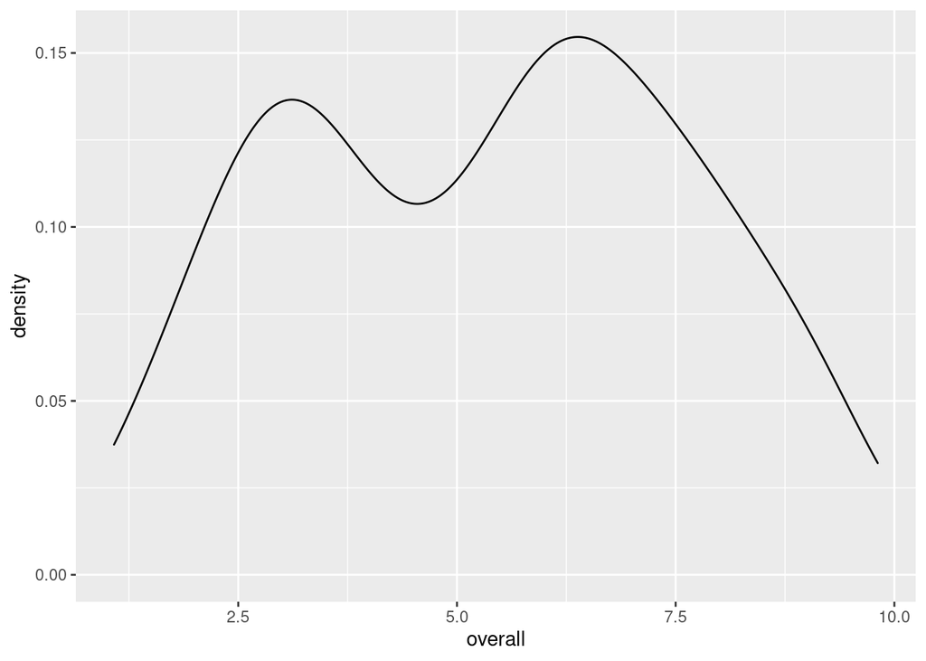

```r
# Set Seed
set.seed(42)

# Plot histogram to view distribution of democracy scores.
democracy %>%
  ggplot(aes(x = overall)) +
  geom_density()
```

Now, let’s see what happens when we take a series of samples. Take a look at the two histograms below. What happens as the sample size $n$ increases? Note that democracy scores can only take values between 0 and 10, while a random variable that is normally distributed can take both positive and negative values. Nonetheless, you can see that as $n$ increases the sampling distribution begins to look symmetric and unimodal.

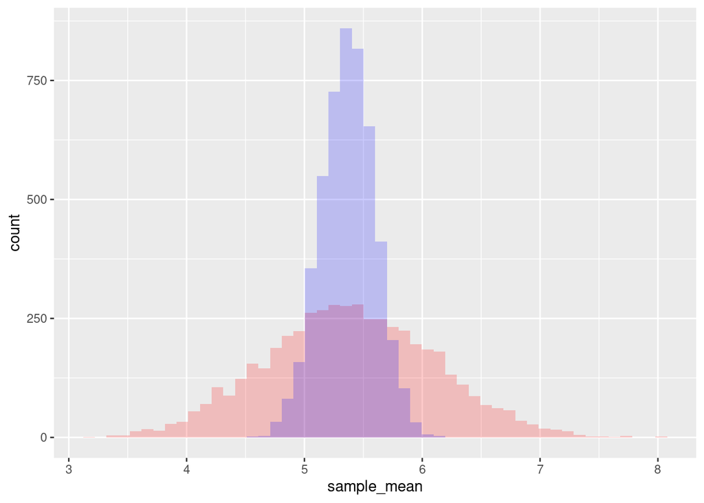

```r
# Remember to type ?rep_sample_n in the console to see what each argument of the function does!
sample_size_10 <- rep_sample_n(tbl = democracy, size = 10, replace = T, reps = 5000) %>%
  summarise(sample_mean = mean(overall), .groups = 'drop')

sample_size_100 <- rep_sample_n(tbl = democracy, size = 100, replace = T, reps = 5000) %>%
  summarise(sample_mean = mean(overall), .groups = 'drop')

ggplot() +
  geom_histogram(data=sample_size_10,aes(x = sample_mean),fill = 'red',alpha = 0.2,bins = 50) +
           geom_histogram(data = sample_size_100,aes(x = sample_mean),fill = 'blue',alpha = 0.2,bins = 50)
```

## Normal Distribution function in R Example

In exercise 1, you will become familiar with various “normal distribution functions” in R. These include

- *pnorm()*: Calculate the probability a normal random variable falls within a specified region.
- *rnorm()*: Generate random numbers from a normal distribution.
- *qnorm()*: Return the value under a normal distribution corresponding to a given probability (the ‘inverse’ of *pnorm()*).

Refer to https://www.statology.org/dnorm-pnorm-rnorm-qnorm-in-r/ for more information about these commands.

Here’s an example: Suppose $X$ is a random variable that is normally distributed with mean $\mu = 10$ and standard deviation $\sigma = 1$ (people sometimes just write this statement as $X \sim N(10,1)$). The distribution of $X$ looks like

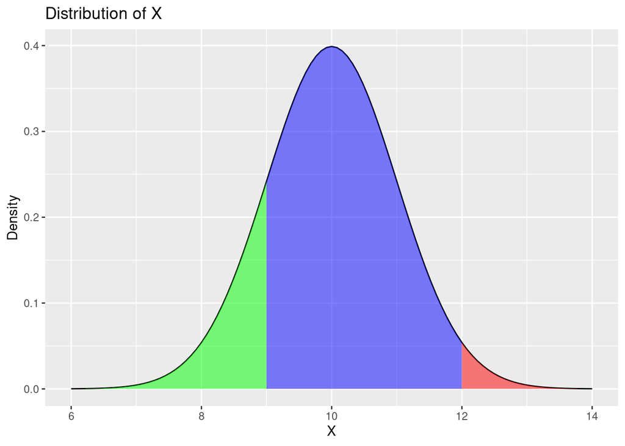

1. The pnorm() function allows us to calculate probabilities. For example, what is $P(X > 12)$, the probability that $X$ is greater than 12? This probability is the area of the red region, which is in the ‘upper tail’ of the distribution. Because of this, we set ‘lower.tail = FALSE’ in the pnorm() function (see below). To find the area of the green region (denoted by $P(X \leq 9)$), we set ‘lower.tail=TRUE’. Notice that the blue region is the complement of the red and green regions.

```r
# Area of red region:
pnorm(q = 12,mean = 10, sd = 1, lower.tail = FALSE)
# Area of green region:
pnorm(q = 9,mean = 10,sd = 1,lower.tail = TRUE)
# "Area of blue region = 1 - Area of red region - Area of green region: "
1 - pnorm(q = 12,mean = 10,sd = 1,lower.tail = FALSE) - pnorm(q = 9,mean = 10, sd = 1,lower.tail = TRUE)
```

2. The qnorm() function gives us the value that corresponds to a given probability. What value of $X$ corresponds to a lower tail area of $0.1586553$? If you ran the code above, then you know that the answer is 9. This is also called the $15.86553^{\text{th}}$ percentile under this distribution. Make sure you specify the tail direction!

```r
qnorm(p = 0.1586553,mean = 10,sd = 1,lower.tail = TRUE)
```

3. To simulate values of $X$, use rnorm(). The $n$ argument specifies how many simulations you want.

```r
Simulations = rnorm(n=500,mean=10,sd=1)
```

## Exercises

### 1 (20 pts.)

Let’s assume that the true standard deviation in democracy scores is $\sigma_{X} = 2.25$. Suppose we sample $n = 100$ countries, in which case the standard error is $\sigma_{\bar{X}} = \frac{2.25}{\sqrt{100}} = 0.225$. Assume that the mean of the sampling distribution is $\mu_{\bar{X}} = 5$. We will assume $\bar{X} \sim N(5, 0.225)$.

1.1. What is the probability that $\bar{X}$ is greater than 5.5? (6 pts)

1.2. What is the 75th percentile of our sampling distribution? (6 pts.) (Hint: this question concerns a percentile, so you’ll need to set ‘lower.tail=TRUE’.)

1.3. Generate and store 1000 random samples from our sampling distribution (8 pts.)

### 2 (20 pts.)

The Binomial distribution is an important discrete distribution. It has two parameters: the size/number of trials $n$ and the probability of a success $p$. Similarly, *dbinom()*, *pbinom()*, *qbinom()*, *rbinom()* are the base R functions for the binomial distribution. They’re basically identical to the normal distribution functions we discussed. Here’s a quick example. Suppose $X \sim \text{Binomial}(n=20,p=0.3)$.

```r
# dbinom() "calculates equalities" like P(X = 3)
dbinom(x = 3, size = 20, prob = 0.3)
# pnbinom() is like the pnorm(). Be careful with the tail specification!
# P(X > 10)
pbinom(q = 10, size = 20,prob = 0.3, lower.tail = FALSE)
# qbinom() is like the qnorm() function: find number '?' such that P(X <= ?) = 0.30
qbinom(p = 0.3,size = 20,prob = 0.3)
```

Refer to https://www.statology.org/dbinom-pbinom-qbinom-rbinom-in-r/ for more information on these commands.

There were 167 countries in the Democracy Score data set. Let’s model future years of Democracy Scores by assuming that 2020 Democracy Scores are representative of subsequent years. Under this model, $X \sim \text{Binomal}\left(p = \frac{96}{167}, n=167\right)$, where $X$ is the number of states with a democracy score of at least 5.

2.1. What is the probability that at least 100 of the countries will have a Democracy Score above 5 in the next set of Democracy Scores? (6 pts.)

2.2 Find the $50^{\text{th}}$ percentile of our $\text{Binomal}\left(p = \frac{96}{167}, n = 167\right)$ distribution using *qbinom()*. (6 pts.)

2.3. Generate and store 100 random samples from our model. (8 pts.)

### 3 (10 pts.)

Use the `select()` function to keep only the variables “Country” and “overall.” Use `arrange()` to order the data by overall score. Which country had the lowest overall democracy score?

### 4 (20 pts.)

There are a variety of sub-measures of democracy in the data set. Please use `mutate` to create a new column in the data set that corresponds to a variable called **diff_score** that measures the *difference* between the country’s electoral process score and their political process score (i.e., electoral process minus political process). What is the mean and median difference in electoral and political process? What does this suggest about which of these two sub-scores tends to be more democratic (i.e. have a higher value)?

### 5 (30 pts.)

Please take and store 1,000 samples of size 50 of the “diff_score” variable that you created in exercise 4. Then, please take and store 1,000 samples of size 500 of the “diff_score” variable. Then, please plot two histograms on the same graph corresponding to each sampling distribution. Do they appear to be normally distributed? Do they have any other distinguishing features? Please discuss what you observe.

## Data Reference

Data for this lab was sourced from *The Economist’s* [Democracy Index](https://www.eiu.com/n/campaigns/democracy-index-2020/)